# 6(d). ARIMA vs ETS Models

Ankit

3/18/2019

The difference between ETS and ARIMA models that all the ETS models are non-stationary but some of the ARIMA models are stationary.

The ETS models with seasonality or non-damped trend or both have two unit roots (i.e., they need two levels of differencing to make them stationary). All other ETS models have one unit root (they need one level of differencing to make them stationary).

While selecting the models between ARIMA and ETS, we cannot compare the models directly using information criteria because both are calculating the likelihood differenctly.

One way to compare ARIMA and ETS model is time series cross-validation.

**Non-Seasonal Data** **Example :- Australian Air traffic data**

```r
library(fpp2)
fets = function(x,h){
  forecast(ets(x), h = h)
}

farima = function(x,h){
  forecast(auto.arima(x), h = h)
}

air = window(ausair, start = 1990)

#To compute the CV error
e1 = tsCV(air, fets , h = 1)
e2 = tsCV(air, farima , h = 1)
mean(e1^2, na.rm = TRUE)
```

```
## [1] 7.864374
```

```r
mean(e2^2, na.rm = TRUE)
```

```
## [1] 9.622164
```

ETS model gives smaller error in this particular case.

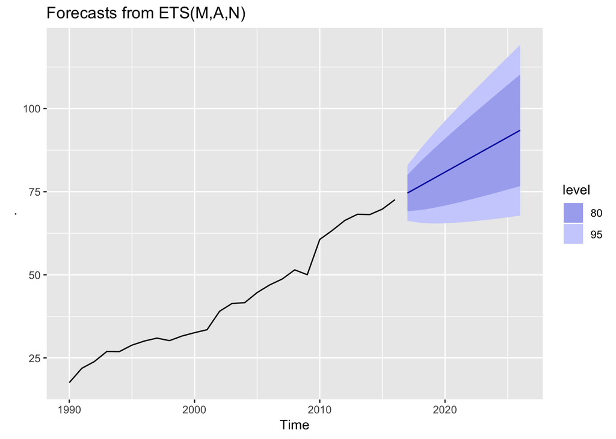

```r
air %>% ets() %>% forecast() %>% autoplot()
```

**Seasonal Data** **Quarterly cement production data**

```r
cement = window(qcement, start = 1988)
#Preparing trainng set for the model
train = window(cement, end = c(2007,4))

## Fitting ARIMA model on training data
fit.arima = auto.arima(train)
summary(fit.arima)
```

```
## Series: train
## ARIMA(2,0,0)(2,1,1)[4] with drift
##
## Coefficients:
##          ar1     ar2    sar1     sar2     sma1   drift
##       0.6470  0.1934  0.0726  -0.2403  -0.8699  0.0105
## s.e.  0.1165  0.1183  0.1602   0.1387   0.1624  0.0030
##
## sigma^2 estimated as 0.01156:  log likelihood=61.45
## AIC=-108.89   AICc=-107.25   BIC=-92.58
##
## Training set error measures:
##                        ME      RMSE        MAE        MPE     MAPE
## Training set -0.005847292 0.1005547 0.07954692 -0.6550081 4.347836
##                   MASE       ACF1
## Training set 0.5434705 -0.0131508
```

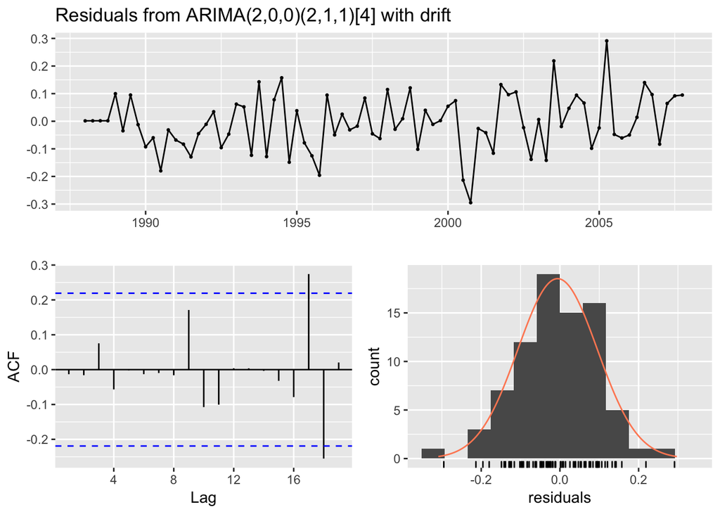

```
##
##  Ljung-Box test
##
## data:  Residuals from ARIMA(2,0,0)(2,1,1)[4] with drift
## Q* = 3.5497, df = 3, p-value = 0.3144
##
## Model df: 6.   Total lags used: 9
```

```r
checkresiduals(fit.arima)
```

The ARIMA model seems to work well as the residuals looks like white noise.

```r
fit.ets = ets(train)
summary(fit.ets)
```

```
## ETS(M,N,M)
##
## Call:
##  ets(y = train)
##
##   Smoothing parameters:
##     alpha = 0.7341
##     gamma = 1e-04
##
##   Initial states:
##     l = 1.6439
##     s = 1.031 1.0439 1.0103 0.9148
##
##   sigma:  0.0581
##
##        AIC       AICc        BIC
## -2.1967020 -0.6411464 14.4774845
##
## Training set error measures:
##                      ME      RMSE        MAE       MPE     MAPE      MASE
## Training set 0.01406512 0.1022079 0.07958478 0.4938163 4.371823 0.5437292
##                     ACF1
## Training set -0.03346295
```

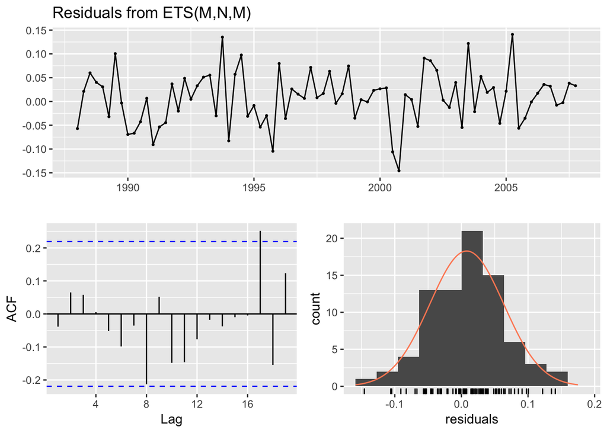

```
##
##  Ljung-Box test
##
## data:  Residuals from ETS(M,N,M)
## Q* = 6.3457, df = 3, p-value = 0.09595
##
## Model df: 6.   Total lags used: 9
```

```r
checkresiduals(fit.ets)
```

This model also does well in capturing all the dynamics in the data, as the residuals similarly appear to be white noise.

Comparing the 2 models

```r
a1 = fit.arima %>% forecast(h = 4*(2013 - 2007) + 1) %>%
  accuracy(qcement)
a1[,c("RMSE","MAE","MAPE","MASE")]
```

```
##                   RMSE        MAE     MAPE      MASE
## Training set 0.1005547 0.07954692 4.347836 0.5434705
## Test set     0.1978199 0.16749423 7.653454 1.1443331
```

```r
a2 = fit.ets %>% forecast(h = 4*(2013 - 2007) + 1) %>%
  accuracy(qcement)
a2[,c("RMSE","MAE","MAPE","MASE")]
```

```
##                   RMSE        MAE     MAPE      MASE
## Training set 0.1022079 0.07958478 4.371823 0.5437292
## Test set     0.1838791 0.15395141 6.986077 1.0518075
```

Notice that the ARIMA model fits the training data slightly better than the ETS model, but that the ETS model provides more accurate forecasts on the test set.

Forecast from ETS Model

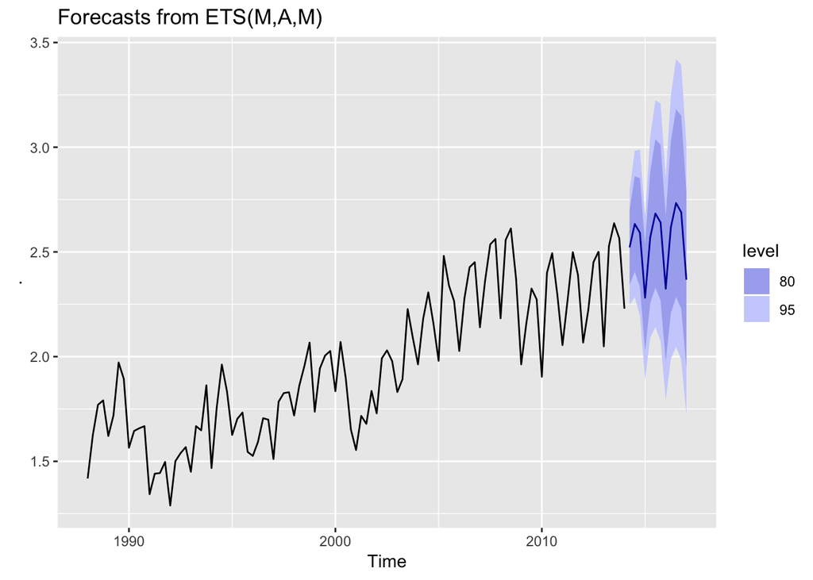

```r
cement %>% ets() %>% forecast(h=12) %>% autoplot()
```